# FFT Dynamic Point

# FFT Dynamic Point

FFT Dynamic Point implementation targeted for AI Engines.

## Library

AI Engine/DSP/Buffer IO

## Description

FFT Dynamic Point implementation targeted for AI Engines. This block supports performing different lengths of FFT on different input data windows. Each window must be preceded by a 256-bit header which describes run-time parameters of that window. The format of the header is described below.

**Note**:

- Every input frame must be prepended by a header.
- If the FFT size (N) is smaller than the frame size, the block takes the N point FFT of the first N samples in the input frame, and discards the rest of the samples in the frame.
- If the frame size is an integer multiple (M) of max FFT size, M FFT iterations will be performed on a given input frame, resulting in multiple iterations of output samples, reducing the number of times the kernel needs to be triggered to process a given number of input data samples. As a result, the overheads incurred during kernel triggering are reduced and overall performance is increased

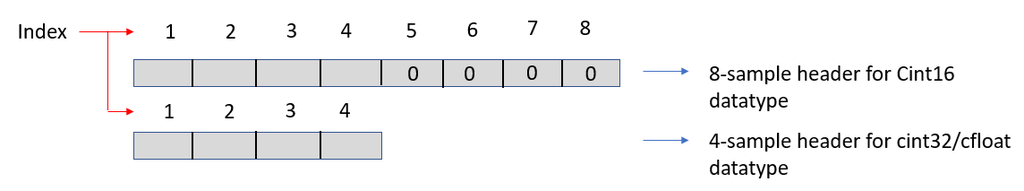

| Index | Field Name | Description |
| --- | --- | --- |
| 1 | Direction | 0 = Inverse FFT 1= Forward FFT |
| 2 | Point size (radix 2 stages) | Point size described as power of 2. For example, value '5' describes a point size of '32' |
| 3 | Reserved | Reserved |
| 4 | Status (output only) | 0 = Legal point size 1 = Illegal point size |

## Parameters

### Main

#### Input data type

Set the data type of the block input. The data type of the input signal to the block must match this setting. Valid types are `cint16`, `cint32`, `cfloat`.

#### Output data type

Set the data type of the block output. Valid types are `cint16`, `cint32`, `cfloat`.

#### Twiddle factor data type

- 32-bit twiddle factors are only supported when the input/output data type is also 32-bit.
- The twiddle factor data type must be an integer type if the input/output data type is an integer type.
- The twiddle factor data type must be `cfloat` if the input/output data type is a float type.

#### FFT Maximum Size

Specifies the maximum FFT size that is supported by Dynamic point FFT. You can perform different lengths of FFT on different input data windows. It must be a power of 2 with a minimum value of 16. The maximum value supported by the library element is 65536.

#### Scale Output down by 2^

Describes the power of 2 shift down applied to output. It must be in the range 0 to 61.

#### Rounding mode

Describes the selection of rounding to be applied during the shift down stage of processing.

The following modes are available:

- **Round to positive infinity:** Round halfway towards positive infinity.
- **Round to negative infinity:** Round halfway towards negative infinity.
- **Round symmetrical to infinity:** Round halfway towards infinity (away from zero).
- **Round symmetrical to zero:** Round halfway towards zero (away from infinity).
- **Round convergent to even:** Round halfway towards nearest even number.
- **Round convergent to odd:** Round halfway towards nearest odd number.

These modes round to the nearest integer. They differ only in how they round for values that are exactly between two integers.

#### Saturation mode

Describes the selection of saturation to be applied during the shift down stage of processing.

#### Use Widget for SSR Kernels

This parameter is applicable to streaming and parallel (SSR>1) implementations of the FFT. These implementations require stream to window conversions on the hardware.

When this parameter is disabled, stream to window conversion will occur within the FFT kernels themselves.

When this parameter is enabled, stream to window conversion will occur on its own AI Engine tiles. This will improve performance at the expense of additional tiles being used.

#### Number of Cascade Stages

This determines the number of kernels the FFT will be divided over in series to improve throughput. For int data types, and FFT size of 2^N, the maximum cascade length is N/2 when N is even and (N+1)/2 when N is odd. For float data type, the maximum cascade length is N.

### Constraints

Click on the button given here to access the constraint manager and add or update constraints for each kernel. If you set the "Number of cascade stages" parameter to a value greater than one, multiple kernels will be used to process the input. You can use the constraint manager to optimize the performance of your design by setting specific constraints for each kernel (in this case, you need to first run your design). Adding constraints will not affect the functional simulation in Simulink. Constraints will only affect the generated graph code, cycle approximate AIE simulation (System C), and behavior in hardware.

If you are using non-default constraints for any of the kernels for the block, an asterisk (*) will be displayed next to the button.

### Header Format

To implement the 32-point size FFT of 'cint16' datatype, the format of the header that should be prepended to the input data window is as follows:

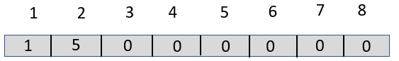

### Input Format

To implement the FFT of different sizes, say, 64, 32 and 128, of type cint32, the format of the input should be as follows.

```
complex([1 6 0 0 ones(1,64) 1 5 0 0 ones(1,32) 1 7 0 0 ones(1,128)])
```

The terms "ones(1,X)" in the expression above are just replacements for the data that we are applying the FFT to.

## Examples

**Click on the images below to open each model.**

[figure not shown]

[figure not shown]

## Related blocks

FFT is another FFT block that uses buffer interface.

FFT Stream is another FFT block that uses stream interface instead of buffer interface and is also SSR capable.

## References

This block uses the Vitis DSP library implementation of FFT. For more details on this implementation please click [here](https://docs.xilinx.com/r/en-US/Vitis_Libraries/dsp/user_guide/L2/func-fft-ifft-aie-only.html).

Copyright (C) 2025 Advanced Micro Devices, Inc. All rights reserved.

SPDX-License-Identifier: MIT